# Thesis_Descriptive Analysis_new

# 6. Age group comparison

```r
agegroup_summary <- df %>%
  group_by(age_group) %>%
  summarise(
    n = n(),
    mean_ls = round(mean(ls, na.rm = TRUE), 2),
    sd_ls = round(sd(ls, na.rm = TRUE), 2),
    mean_cog = round(mean(cog_index, na.rm = TRUE), 2),
    sd_cog = round(sd(cog_index, na.rm = TRUE), 2),
    mean_income = round(mean(income, na.rm = TRUE), 2),
    sd_income = round(sd(income, na.rm = TRUE), 2)
  )

knitr::kable(agegroup_summary, caption = "Summary Statistics by Age Group")
```

Summary Statistics by Age Group

| age_group | n | mean_ls | sd_ls | mean_cog | sd_cog | mean_income | sd_income |
| --- | --- | --- | --- | --- | --- | --- | --- |
| Under 65 | 9731 | 7.42 | 1.92 | 0.33 | 0.91 | 2040.93 | 2445.59 |
| 65 to 74 | 6428 | 7.40 | 2.05 | -0.01 | 0.89 | 1702.26 | 2267.02 |
| Plus 75 | 4733 | 7.17 | 2.18 | -0.58 | 0.93 | 1327.43 | 1925.47 |

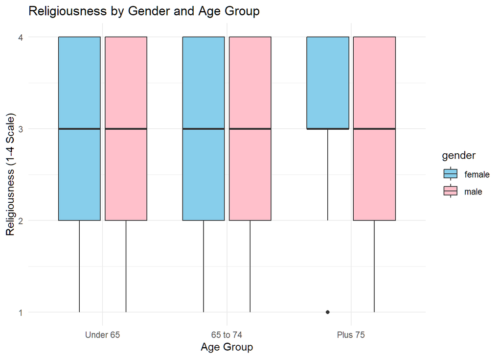

```r
# By Gender & Age Group

# Religiousness
ggplot(df, aes(x = age_group, y = child_sig, fill = gender)) +
  geom_boxplot() +
  labs(
    title = "Religiousness by Gender and Age Group",
    x = "Age Group",
    y = "Religiousness (1-4 Scale)"
  ) +
  theme_minimal() +
  scale_fill_manual(values = c("skyblue", "pink"))
```

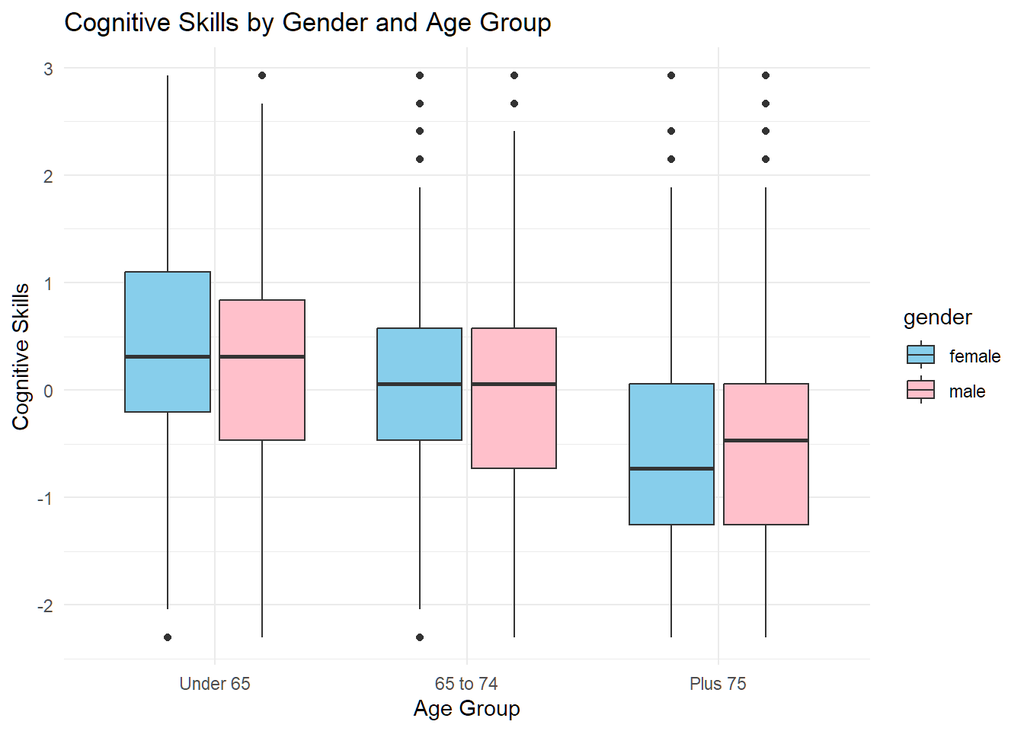

```r
# Cognitive skills
ggplot(df, aes(x = age_group, y = cog_index, fill = gender)) +
  geom_boxplot() +
  labs(
    title = "Cognitive Skills by Gender and Age Group",
    x = "Age Group",
    y = "Cognitive Skills"
  ) +
  theme_minimal() +
  scale_fill_manual(values = c("skyblue", "pink"))
```

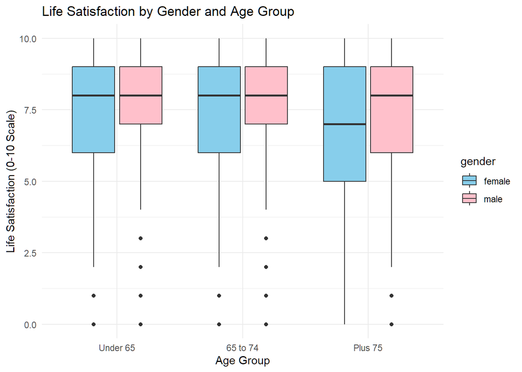

```r
# Life satisfaction
ggplot(df, aes(x = age_group, y = ls, fill = gender)) +
  geom_boxplot() +
  labs(
    title = "Life Satisfaction by Gender and Age Group",
    x = "Age Group",
    y = "Life Satisfaction (0-10 Scale)"
  ) +
  theme_minimal() +
  scale_fill_manual(values = c("skyblue", "pink"))
```

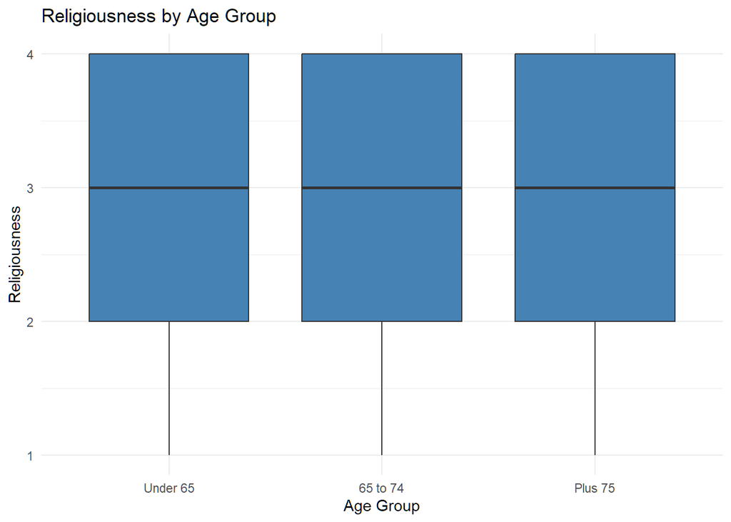

```r
#Religiousness by Age Group
ggplot(df, aes(x = age_group, y = child_sig)) +
  geom_boxplot(fill = "steelblue") +
  labs(title = "Religiousness by Age Group", x = "Age Group", y = "Religiousness") +
  theme_minimal()
```

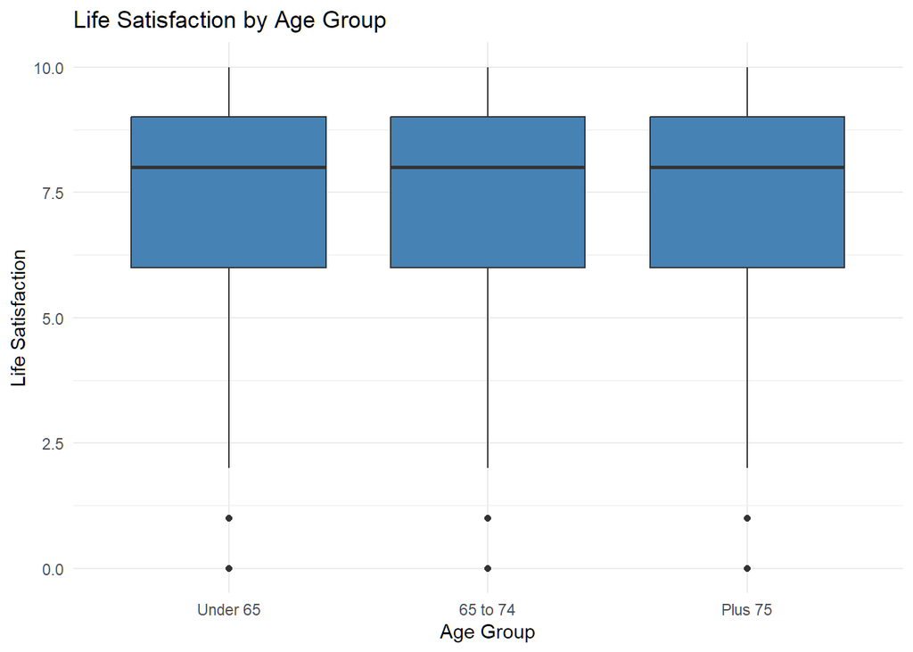

```r
# Life Satisfaction by Age Group
ggplot(df, aes(x = age_group, y = ls)) +
  geom_boxplot(fill = "steelblue") +
  labs(title = "Life Satisfaction by Age Group", x = "Age Group", y = "Life Satisfaction") +
  theme_minimal()
```

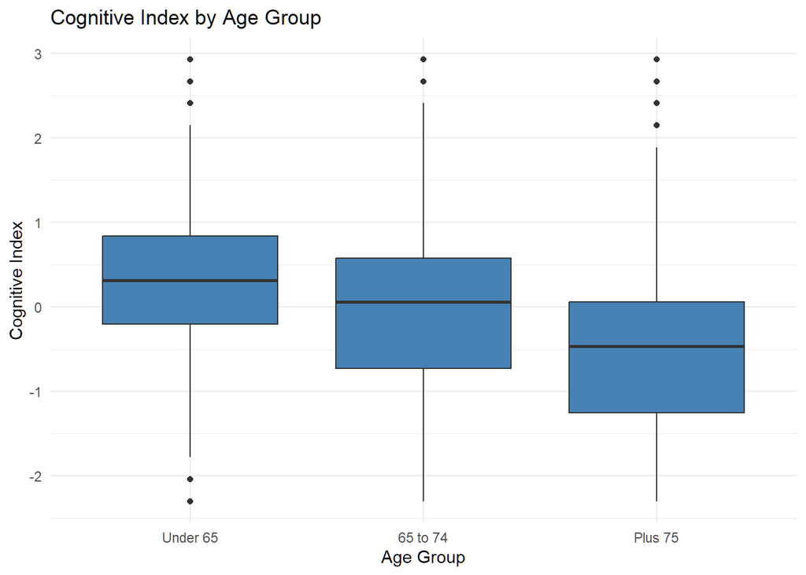

```r
# Cognitive Index by Age Group
ggplot(df, aes(x = age_group, y = cog_index)) +
  geom_boxplot(fill = "steelblue") +
  labs(title = "Cognitive Index by Age Group", x = "Age Group", y = "Cognitive Index") +
  theme_minimal()
```

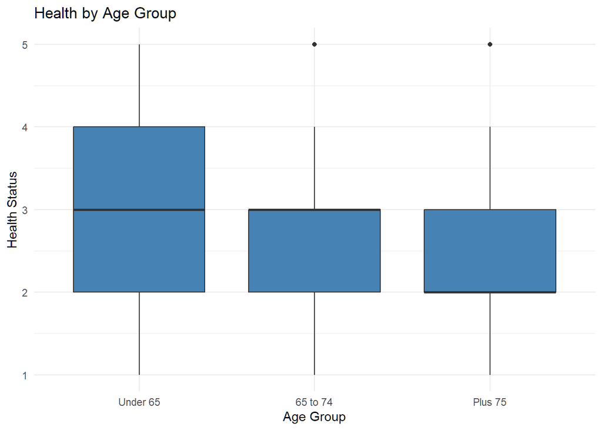

```r
# Health by Age Group
ggplot(df, aes(x = age_group, y = health)) +
  geom_boxplot(fill = "steelblue") +
  labs(title = "Health by Age Group", x = "Age Group", y = "Health Status") +
  theme_minimal()
```

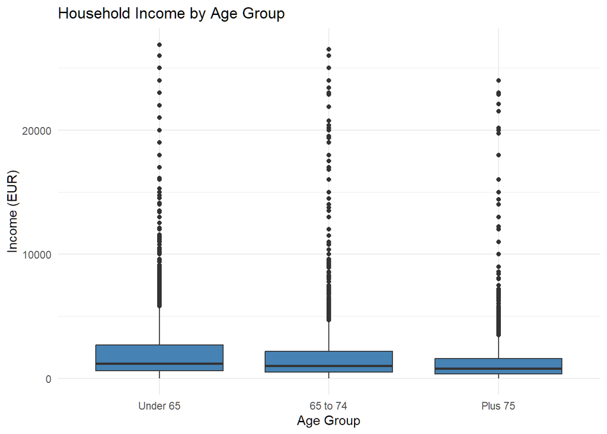

```r
# Income by Age Group
ggplot(df, aes(x = age_group, y = income)) +
  geom_boxplot(fill = "steelblue") +
  labs(title = "Household Income by Age Group", x = "Age Group", y = "Income (EUR)") +
  theme_minimal()
```

# 7. Comparison by health status

```r
# Reorder health labels
df$health_label <- factor(df$health_label,
                           levels = c("Poor", "Fair", "Good", "Very good", "Excellent"))
```

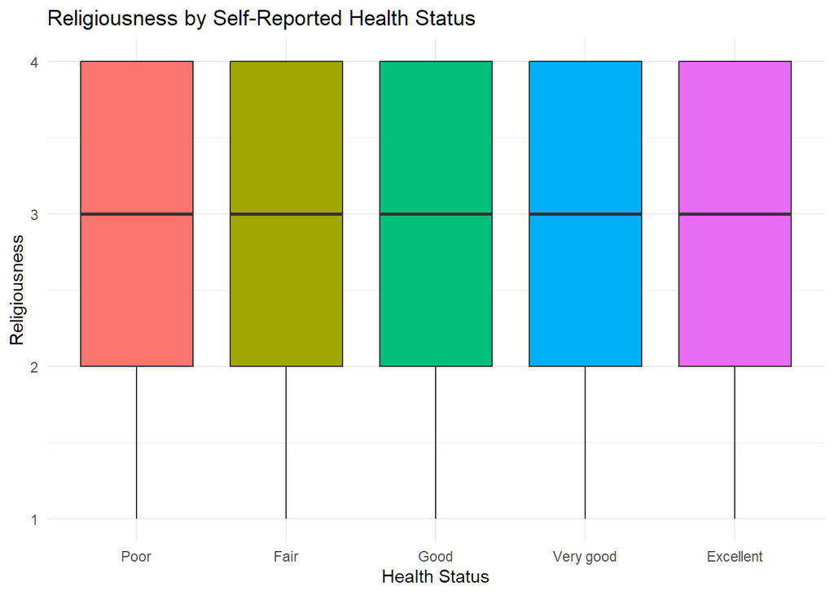

```r
ggplot(df, aes(x = health_label, y = child_sig, fill = health_label)) +
  geom_boxplot() +
  labs(
    title = "Religiousness by Self-Reported Health Status",
    x = "Health Status",
    y = "Religiousness"
  ) +
  theme_minimal() +
  theme(legend.position = "none")
```

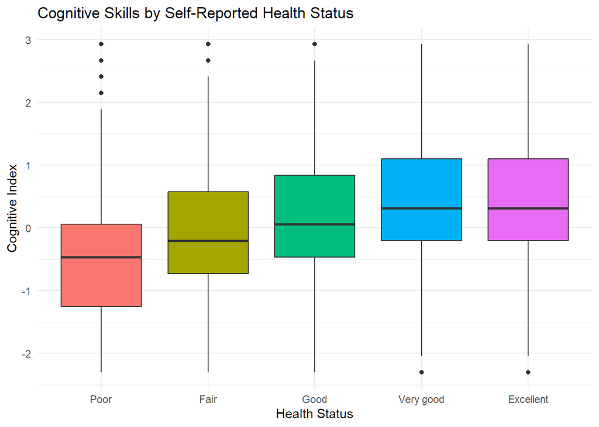

```r
ggplot(df, aes(x = health_label, y = cog_index, fill = health_label)) +
  geom_boxplot() +
  labs(
    title = "Cognitive Skills by Self-Reported Health Status",
    x = "Health Status",
    y = "Cognitive Index"
  ) +
  theme_minimal() +
  theme(legend.position = "none")
```

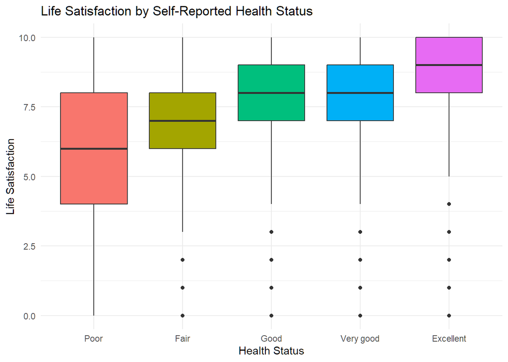

```r
ggplot(df, aes(x = health_label, y = ls, fill = health_label)) +
  geom_boxplot() +
  labs(
    title = "Life Satisfaction by Self-Reported Health Status",
    x = "Health Status",
    y = "Life Satisfaction"
  ) +
  theme_minimal() +
  theme(legend.position = "none")
```

# 8. Gender-wise inspection

By gender & age group

```r
# Table with counts and percentages
gender_age_table <- df %>%
  group_by(age_group, gender) %>%
  summarise(count = n(), .groups = "drop") %>%
  mutate(percentage = round(100 * count / sum(count), 1))

kable(gender_age_table,
      caption = "Number and Percentage of Participants by Gender and Age Group")
```

Number and Percentage of Participants by Gender and Age Group

| age_group | gender | count | percentage |
| --- | --- | --- | --- |
| Under 65 | female | 5774 | 27.6 |
| Under 65 | male | 3957 | 18.9 |
| 65 to 74 | female | 3674 | 17.6 |
| 65 to 74 | male | 2754 | 13.2 |
| Plus 75 | female | 2961 | 14.2 |
| Plus 75 | male | 1772 | 8.5 |

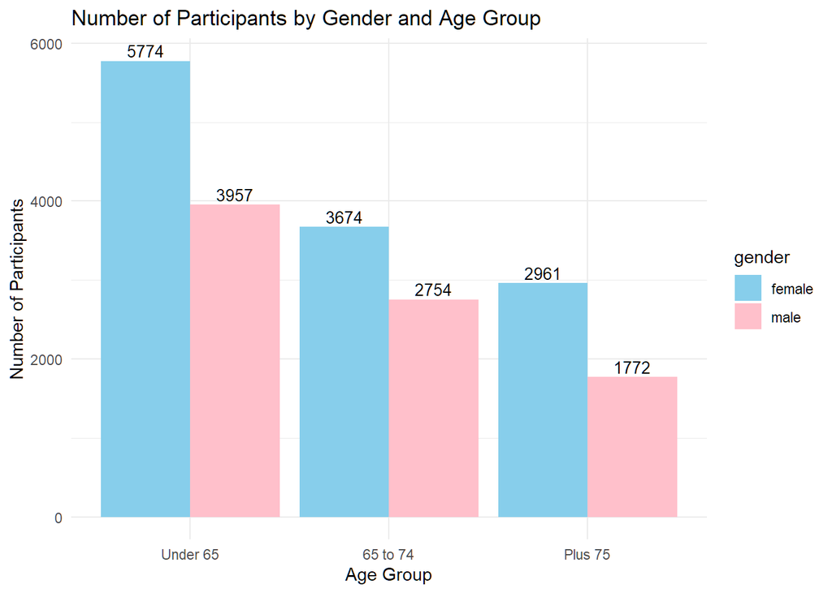

```r
# Create dataset
gender_age_counts <- df %>%
  group_by(gender, age_group) %>%
  summarise(count = n(), .groups = "drop")

# plot
ggplot(gender_age_counts, aes(x = age_group, y = count, fill = gender)) +
  geom_bar(stat = "identity", position = position_dodge(width = 0.9)) +
  geom_text(aes(label = count),
            position = position_dodge(width = 0.9),
            vjust = -0.3, size = 3.5) +
  labs(
    title = "Number of Participants by Gender and Age Group",
    x = "Age Group",
    y = "Number of Participants"
  ) +
  theme_minimal() +
  scale_fill_manual(values = c("skyblue", "pink"))
```

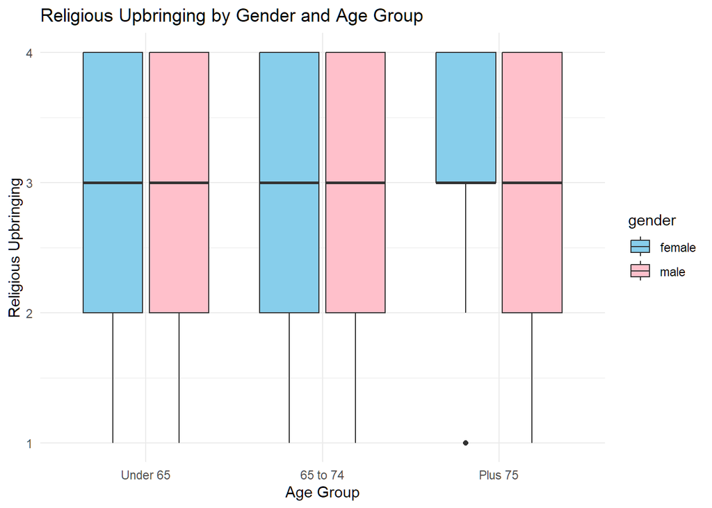

```r
# religiousness
ggplot(df, aes(x = age_group, y = child_sig, fill = gender)) +
  geom_boxplot() +
  labs(
    title = "Religious Upbringing by Gender and Age Group",
    x = "Age Group",
    y = "Religious Upbringing"
  ) +
  theme_minimal() +
  scale_fill_manual(values = c("skyblue", "pink"))
```

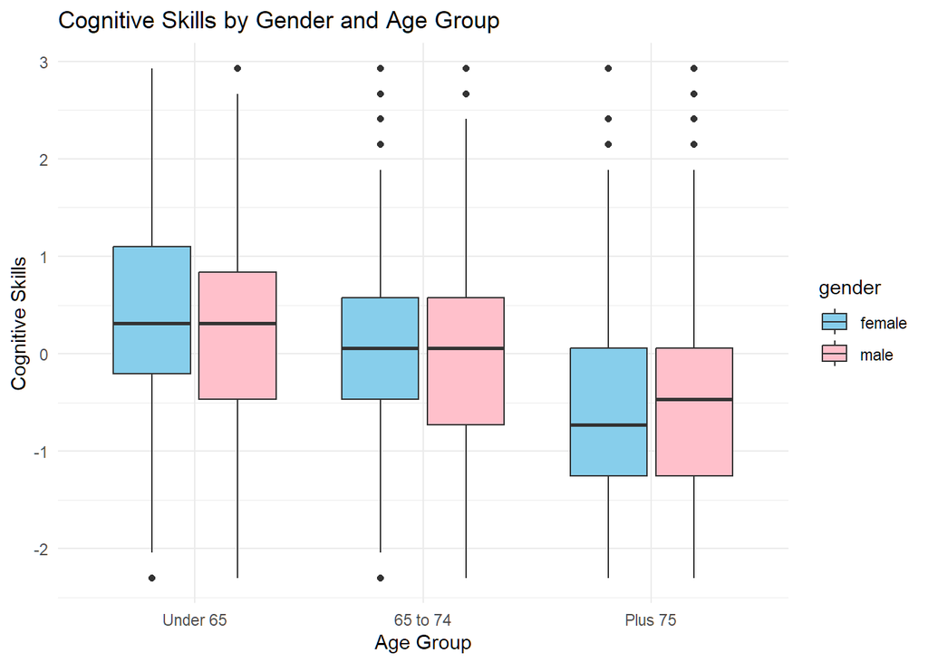

```r
# cog skills
ggplot(df, aes(x = age_group, y = cog_index, fill = gender)) +
  geom_boxplot() +
  labs(
    title = "Cognitive Skills by Gender and Age Group",
    x = "Age Group",
    y = "Cognitive Skills"
  ) +
  theme_minimal() +
  scale_fill_manual(values = c("skyblue", "pink"))
```

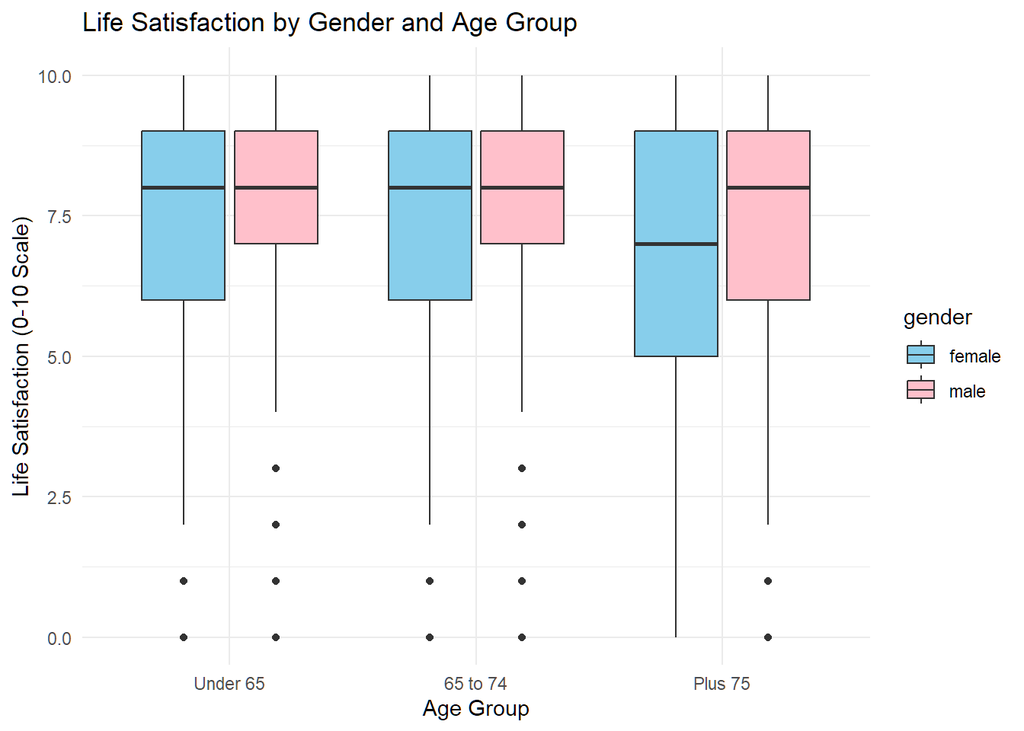

```r
#life satisfaction
ggplot(df, aes(x = age_group, y = ls, fill = gender)) +
  geom_boxplot() +
  labs(
    title = "Life Satisfaction by Gender and Age Group",
    x = "Age Group",
    y = "Life Satisfaction (0-10 Scale)"
  ) +
  theme_minimal() +
  scale_fill_manual(values = c("skyblue", "pink"))
```

# Additional Inspection

## Income group

Life satisfaction by income group

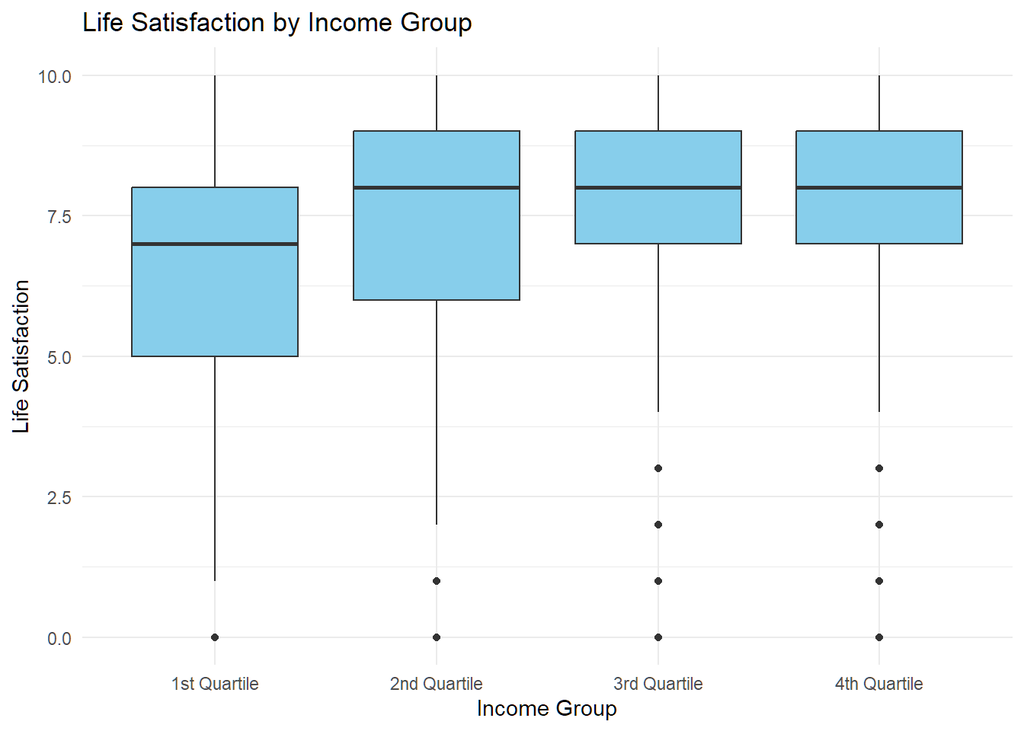

```r
ggplot(df, aes(x = income_group, y = ls)) +
  geom_boxplot(fill = "skyblue") +
  labs(
    title = "Life Satisfaction by Income Group",
    x = "Income Group",
    y = "Life Satisfaction"
  ) +
  theme_minimal()
```

# Save file

```r
write.csv(df, "df_new.csv", row.names = FALSE)
```

# References

[1] Field, A. P. (2009). *Discovering statistics using SPSS: (and sex and drugs and Rock N’ Roll)* (3rd ed.). SAGE.

# Additional Mandatory References

Bergmann, M., A. Scherpenzeel and A. Börsch-Supan (Eds.) (2019). *SHARE Wave 7 Methodology: Panel Innovations and Life Histories*. Munich: MEA, Max Planck Institute for Social Law and Social Policy.

Bergmann, M., T. Kneip, G. De Luca and A. Scherpenzeel (2019). *Survey participation in the Survey of Health, Ageing and Retirement in Europe (SHARE), Wave 1-7*. Based on Release 7.0.0. SHARE Working Paper Series: 41-2019. Munich: MEA, Max Planck Institute for Social Law and Social Policy.

Börsch-Supan, A., M. Brandt, C. Hunkler, T. Kneip, J. Korbmacher, F. Malter, B. Schaan, S. Stuck and S. Zuber (2013). *Data Resource Profile: The Survey of Health, Ageing and Retirement in Europe (SHARE)*. International Journal of Epidemiology. DOI: [**10.1093/ije/dyt088**](https://doi.org/10.1093/ije/dyt088).

SHARE-ERIC (2024). *Survey of Health, Ageing and Retirement in Europe (SHARE) Wave 7*. Release version: 9.0.0. SHARE-ERIC. Data set. DOI: [**10.6103/SHARE.w7.900**](http://dx.doi.org/10.6103/SHARE.w7.900)